# The ABC of Computational Text Analysis

#3 Setting up your Development Environment

Alex Flückiger

Faculty of Humanities and Social Sciences  
University of Lucerne

March 17, 2023

## Outline

- research workflow 📑
- interacting with computers 🪄
- installation of programs 🔨

## Recap last Lecture

- textual data is challenging
- machine-readable data

# The Zen of Organizing

## Research means Organizing

### How a computational approach helps

- scripts as documentation 📝
- efficient automation ♻️
  - “don’t repeat yourself”
- less error-prone 🤦‍♀️ 🤦‍♂️
- reproducible 💯

## Organizing Literature

- manage literature in one place
- generating bibliographies
- collect with a click in your browser

[figure not shown]

[Zotero](https://www.zotero.org/) is a free, open-source software for managing scientific literature

# Computers

## Two Trends in Computing

- everyday, mobile, cloud-centered, touch/click-based approach
  - single-purpose application
  - smartphones + tablets
- engineering, open-source, machine-oriented approach
  - powerful due to modularity
  - workflow for data science

(see also Healy 2019)

[figure not shown]

Apple Original iPhone (2007)

## Operating Systems (OS)

### Between hardware and programs

- Microsoft Windows
- macOS
- Linux-based systems 🤓

## User Interfaces

### graphical user interface (GUI)

[figure not shown]

### command line interface (CLI)

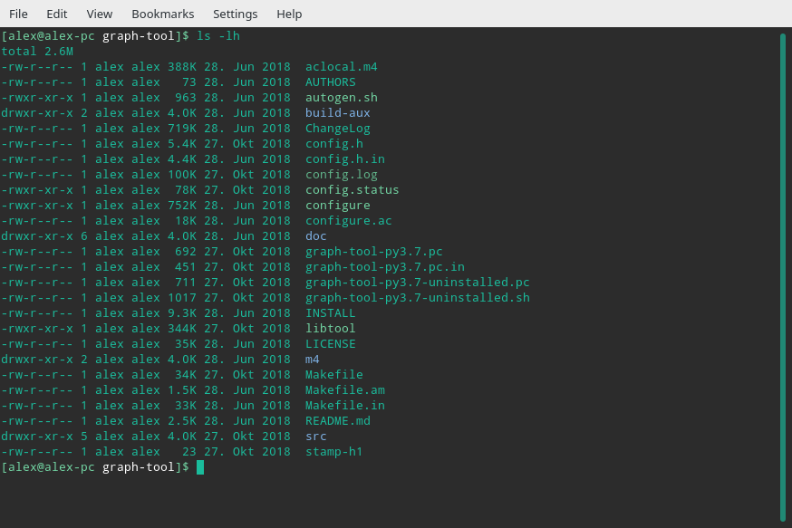

## **“An awesome Programmer saves the World”**

## Human-Machine Interaction

### How to tell the computer effienctly

- text commands instead of clicks
- similar to human languages
  - syntax (form)
  - semantics (meaning)
- computers are literalists

## Programming

- command languages
  - Bourne-Again shell (Bash), since 1989
- programming languages
  - Python, R, Java, C++ etc.
- instructions → program ≡ algorithm
  - cooking

## Package Manager

- automation of software installation
  - system: apt, Homebrew
  - Python: pip, conda
- software dependencies
- similar to app stores

## Open-Source is a Mindset

### Standing on the shoulders of giants

- free + open software
- cross-platform portability
- collaboration
  - share + reuse
- helpful community

## Resources everyone is using

- [Stack Overflow](https://stackoverflow.com/questions)
  - where you get answers to technical questions
- [GitHub](https://github.com/)
  - where you find open software

## Learning by doing, doing by Googleing. 🤸‍♀️🤸‍♂️

# Set up your System

## Backup 👹

You don’t need it until you desperately need it!

## Setting up your Development Environment

### Installation

- Python 3.8
  - packages for NLP + visualization
- Tesseract
- various Bash tools
- VS Code Editor

👉 Follow the [installation guide](https://aflueckiger.github.io/KED2023/materials/installation_guide.pdf) for your OS.

# Relax. It takes a while.

## VS Code Editor

### The Microsoft Word for coding

- powerful integrated development environment (IDE)
- cross-platform
- interactive analysis

[figure not shown]

Write your first Python script in [VS Code](https://code.visualstudio.com/)

## First Steps in Python

Learn Python with interactive tutorials

- [Python Principles](https://pythonprinciples.com)
- [LearnPython](https://www.learnpython.org/en/Welcome)

## Readings

### optional: pimp your workflow

Healy, Kieran. 2019. “The Plain Person’s Guide to Plain Text Social Science.” [online](https://kieranhealy.org/publications/plain-person-text/).

# Questions?

## References

Healy, Kieran. 2019. “The Plain Person’s Guide to Plain Text Social Science.” https://kieranhealy.org/publications/plain-person-text/.